# Test Question 1

Yuval Saraf

06/07/2020

הורידו את הקובץ kobe.csv שנמצא בלינק הבא:  
https://drive.google.com/file/d/1eS7Tf7lM-c1d54FZq2YXV8jBKLSRmut4/view?usp=sharing  
הקובץ מכיל את הנתונים הסטטיסטיים של שחקן הכדורסל קובי ברייאנט במשך 20 שנה - מעונת 1996-97 עד לעונת 2015-16.  
כל שורה בקובץ מתארת זריקה אחת לסל שביצע קובי במהלך המשחק וכל עמודה מתארת שדה נתונים מסוים.  
כדי להדגיש מהם השדות החשובים בקובץ נקח לדוגמא על השורה הראשונה (אחרי שורת הכותרות):

- season - העונה שבה התרחש המשחק (בכל עונה יש כמה עשרות משחקים). עבור השורה הראשונה זו עונת 2000-01.
- game_id - מספר מזהה ייחודי עבור כל משחק. עבור השורה הראשונה המספר המזהה הוא 20000012.
- shot_type - סוג הזריקה לסל: או זריקה מטווח קצר עבור שתי נקודות 2PT Field Goal או זריקה מטווח ארוך עבור שלוש נקודות 3PT Field Goal.  
  עבור השורה הראשונה זו הייתה זריקה לשתי נקודות 2PT Field Goal.
- shot_made_flag - האם הזריקה נכנסה לסל או לא.  
  1 אומר שהזריקה נכנסה, 0 אומר שהזריקה לא נכנסה ו- ערך חסר (NA) אומר שאין את הנתון הזה.  
  עבור השורה הראשונה אין את הנתון, כלומר אנחנו לא יודעים אם הזריקה נכנסה או לא.

המטרה בשאלה זו היא לחקור האם הסיכוי לקלוע לשלוש נקודות מושפע חיובית (יד חמה), שלילית (אנטי-יד חמה) או כלל לא, מהזריקה הקודמת לשלוש נקודות.  
לדוגמא עבור אנטי-יד חמה, אם הזריקה הקודמת לשלוש נכנסה לסל אז הסיכוי שהזריקה הנוכחית לשלוש תיכנס לסל קטן ולהפך - אם הזריקה הקודמת לשלוש לא נכנסה לסל אז הסיכוי שהזריקה הנוכחית לשלוש תיכנס לסל עולה.  
שימו לב שיש טעם לבדוק זאת רק ברמת המשחק הבודד (אנחנו משערים שהזריקה האחרונה לשלוש במשחק הקודם לא תשפיע על הסיכוי לקליעה לשלוש בזריקה הראשונה במשחק הבא), ולכן בסעיף ב׳ נפרק את הקובץ לתתי טבלאות לפי ה- game_id.

1. סעיף א׳ (15 נקודות):  
   קראו את הקובץ לתוך טבלה ב- R.  
   צרו גרף המתאר את מספר הזריקות של קובי לשלוש נקודות (בסעיף זה לא משנה אם הזריקה נכנסה לסל או לא), כפונקציה של עונת המשחקים.  
   למשל, העונה הראשונה בקובץ היא 1996-97 ובה זרק קובי 159 פעמים לשלוש נקודות, כך שבגרף ערך ה-X יהיה 1 וערך ה-Y יהיה 159.  
   העונה השנייה בקובץ היא 1997-98 ובה זרק קובי 234 פעמים לשלוש נקודות, כך שבגרף ערך ה-X יהיה 2 וערך ה-Y יהיה 234, וכך הלאה עד עונת 2015-16.  
   הקפידו על כותרות לצירים בגרף.

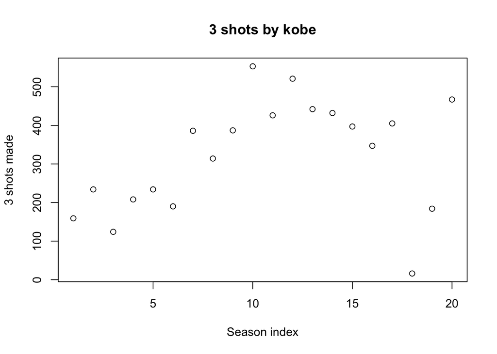

   ```r
   kobe = read.csv("kobe.csv", header = TRUE);
   seasons = unique(kobe$season);
   seasonsOrdered = seasons[order(seasons)];
   threeShortPerSeason = Map(function(season) { return (nrow(kobe[kobe$season == season & kobe$shot_type == "3PT Field Goal", ])); }, seasonsOrdered);
   plot(unlist(threeShortPerSeason), main="3 shots by kobe", xlab="Season index", ylab="3 shots made");
   ```

2. סעיף ב׳ (15 נקודות):  
   צרו טבלה מצומצמת שבה יש רק את השורות המתארות את הזריקות לשלוש נקודות ורק את שתי העמודות הבאות: “shot_made_flag”, “game_id”.  
   הציגו 5 שורות ראשונות מטבלה זו.  
   פצלו את הטבלה המצומצמת לרשימה (list) שכל איבר שלה יכיל נתונים רק עבור משחק אחד.  
   כלומר, נתונים רק עבור game_id אחד.  
   הציגו 5 איברים ראשונים מרשימה זו.

   ```r
   kobeThreeShots = kobe[kobe$shot_type == "3PT Field Goal", c("game_id", "shot_made_flag")];
   head(kobeThreeShots, n = 5);
   ```

   ```
   ##     game_id shot_made_flag
   ## 11 20000012              0
   ## 18 20000019              1
   ## 28 20000019              0
   ## 40 20000047              1
   ## 55 20000049             NA
   ```

   ```r
   game_ids = unique(kobeThreeShots$game_id);
   kobeThreeShotsByGameId = Map(function(game_id) { return (kobeThreeShots[kobeThreeShots$game_id == game_id, ]);}, game_ids)
   names(kobeThreeShotsByGameId) = game_ids;
   head(kobeThreeShotsByGameId, n = 5);
   ```

   ```
   ## $`20000012`
   ##     game_id shot_made_flag
   ## 11 20000012              0
   ##
   ## $`20000019`
   ##     game_id shot_made_flag
   ## 18 20000019              1
   ## 28 20000019              0
   ##
   ## $`20000047`
   ##     game_id shot_made_flag
   ## 40 20000047              1
   ##
   ## $`20000049`
   ##     game_id shot_made_flag
   ## 55 20000049             NA
   ## 56 20000049              0
   ## 57 20000049              1
   ## 60 20000049             NA
   ##
   ## $`20000058`
   ##     game_id shot_made_flag
   ## 68 20000058              0
   ## 72 20000058              1
   ## 75 20000058              0
   ```

3. סעיף ג׳ (15 נקודות):  
   כתבו פונקציה count_events שיודעת לקבל וקטור עם ערכי shot_made_flag עבור משחק אחד, ולהחזיר וקטור (או מטריצה) עם ארבעת הערכים הבאים לפי הסדר הזה:
   - מספר הזריקות שנכנסו לסל בעקבות זריקות שנכנסו לסל
   - מספר הזריקות שנכנסו לסל בעקבות זריקות שלא נכנסו לסל
   - מספר הזריקות שלא נכנסו לסל בעקבות זריקות שנכנסו לסל
   - מספר הזריקות שלא נכנסו לסל בעקבות זריקות שלא נכנסו לסל
     - For example

       ```bash
       > vec<-c(1, 0, NA, 1, 0, 0, 1, 0)
       > matrix_events<-count_events(vec)
       > matrix_events[1] #  counting 1,1 events
       [1] 0
       > matrix_events[2] #  counting 0,1 events
       [1] 1
       > matrix_events[3] #  counting 1,0 events
       [1] 3
       > matrix_events[4] # counting 0,0 events
       [1] 1
       ```

   ```r
   count_events = function (shot_made_flags) {
     n = length(shot_made_flags);
     vec = shot_made_flags[1:(n-1)];
     vec_off = shot_made_flags[2:n] # create offset of 1 between vec and vec_off
     counts = rep(c(0), 4);
     counts[1] = sum(((!is.na(vec))&vec==1)&((!is.na(vec_off))&vec_off==1)) # count 1,1 events
     counts[2] = sum(((!is.na(vec))&vec==0)&((!is.na(vec_off))&vec_off==1)) # count 0,1 events
     counts[3] = sum(((!is.na(vec))&vec==1)&((!is.na(vec_off))&vec_off==0)) # count 1,0 events
     counts[4] = sum(((!is.na(vec))&vec==0)&((!is.na(vec_off))&vec_off==0)) # count 0,0 events
     return (counts);
   }
   vec = c(1, 0, NA, 1, 0, 0, 1, 0);
   matrix_events = count_events(vec);
   matrix_events[1]; # Should be 0
   ```

   ```
   ## [1] 0
   ```

   ```r
   matrix_events[2]; # Should be 1
   ```

   ```
   ## [1] 1
   ```

   ```r
   matrix_events[3]; # Should be 3
   ```

   ```
   ## [1] 3
   ```

   ```r
   matrix_events[4]; # Should be 1
   ```

   ```
   ## [1] 1
   ```

4. סעיף ד׳ (15 נקודות):  
   כתבו פונקציה count_events_all_games שיודעת לקבל את הרשימה (list) מסעיף ב׳ ולהחזיר:  
   (א) את הסיכוי שזריקה לשלוש תיכנס לסל בהינתן שהזריקה הקודמת לשלוש נכנסה לסל, ו- (ב) את הסיכוי שזריקה לשלוש תיכנס לסל בהינתן שהזריקה הקודמת לשלוש לא נכנסה לסל.

   ```r
   count_events_all_games<-function(SplitTable,MinimumNumber3PT,Permutation_flag){
     #INPUT: Split tables, each with one game
     #INPUT: MinimumNumber3PT - the minimum number of 3PT in a game to analyze
     #INPUT: Permutation_flag - 1 for permutations and 0 for no permutations
     #OUTPUT: probability of a hit after a miss and the probability of a hit after a hit
   }
   ```

   שימו לב שפונקציה זו מקבלת כקלט גם את המספר המינימלי של זריקות לשלוש עבור משחק בודד, כלומר אם במשחק מסוים יש פחות זריקות לשלוש מאשר ערך זה אין לנתח את המשחק. קלט נוסף הוא דגל Permutation_flag שכאשר הוא 1 יש צורך לערבב בצורה אקראית את הסדר של ערכי shot_made_flag וכאשר הוא 0 משאירים את הסדר של ערכי shot_made_flag כמו שהוא.

   הדרכה: על פונקציה זו לקרוא לפונקציה מסעיף ג׳ עם ערכי shot_made_flag (מעורבבים או לא לפי Permutation_flag) עבור כל משחק בודד, ואז לסכום את כל הערכים המתקבלים עבור כל המשחקים שעומדים בתנאי של MinimumNumber3PT.  
   לאחר הסכימה על פונקציה זו לחשב את הסיכויים המתוארים ב- (א) ו- (ב) למעלה.

   ```r
   count_events_all_games = function(SplitTable, MinimumNumber3PT, Permutation_flag) {
     eventsSum = Reduce(function(agg, game_info) {
       shot_made_flags = game_info$shot_made_flag;
       if (Permutation_flag) {
         shot_made_flags = sample(game_info$shot_made_flag);
       }
       number3PT = length(shot_made_flags);

       events = rep(c(0), 4);
       if (number3PT >= MinimumNumber3PT) {
         events = count_events(shot_made_flags);
       }

       return (agg + events);
     }, SplitTable, rep(c(0), 4));

     sumOfFirstHit = eventsSum[1] + eventsSum[3];

     return (
       list(
         probability_of_hit_after_hit = eventsSum[1] / sumOfFirstHit,
         probability_of_hit_after_miss = eventsSum[3] / sumOfFirstHit
       )
     );
   }

   # Test
   count_events_all_games(kobeThreeShotsByGameId, 3, TRUE);
   ```

   ```
   ## $probability_of_hit_after_hit
   ## [1] 0.3208042
   ##
   ## $probability_of_hit_after_miss
   ## [1] 0.6791958
   ```

5. סעיף ה׳ (15 נקודות):
   1. בעזרת הפונקציה מסעיף ד׳, עבור כל המשחקים שעומדים בתנאי של MinimumNumber3PT=2, חשבו (א) את הסיכוי שזריקה לשלוש תיכנס לסל בהינתן שהזריקה הקודמת לשלוש נכנסה לסל, ו- (ב) את הסיכוי שזריקה לשלוש תיכנס לסל בהינתן שהזריקה הקודמת לשלוש לא נכנסה לסל.  
      האם התוצאות מרמזות על אפשרות של יד חמה או אנטי-יד חמה?

      ```r
      (original_probability = count_events_all_games(kobeThreeShotsByGameId, 2, FALSE));
      ```

      ```
      ## $probability_of_hit_after_hit
      ## [1] 0.3148148
      ##
      ## $probability_of_hit_after_miss
      ## [1] 0.6851852
      ```

      התוצאות מרמזות על אנטי-יד חמה.
   2. על מנת לבדוק אם התוצאה ב- (1) משמעותית סטטיסטית, חזרו על (1), אבל הפעם עם מבחן פרמוטציות. בצעו 1000 פרמוטציות ועבור כל פרמוטציה חשבו את ההפרש בין הסיכויים: הסיכוי המתואר ב- (ב) פחות הסיכוי המתואר ב-(א).  
      כמה פעמים ההפרש הזה היה גדול או שווה להפרש שהתקבל בנתונים הלא מעורבבים (non permutated)?  
      נסחו מהי השערת האפס.  
      על סמך מבחן הפרמוטציות, מהו ה- p-value והאם צריך לדחות את השערת האפס?

      ```r
      set.seed(1);
      numOfPerm = 1000;
      permutated_probabilities = Reduce(
        function(agg, index) {
          permutated_probability = count_events_all_games(kobeThreeShotsByGameId, 2, TRUE);
          if (is.null(agg)) {
            return (permutated_probability);
          }

          return (
            list(
              probability_of_hit_after_hit = append(agg$probability_of_hit_after_hit, permutated_probability$probability_of_hit_after_hit),
              probability_of_hit_after_miss = append(agg$probability_of_hit_after_miss, permutated_probability$probability_of_hit_after_miss)
            )
          )
        },
        1:numOfPerm,
        NULL
      );
      original_diff = original_probability$probability_of_hit_after_miss - original_probability$probability_of_hit_after_hit;
      permutated_diffs = permutated_probabilities$probability_of_hit_after_miss - permutated_probabilities$probability_of_hit_after_hit;
      times_permutated_was_bigger = sum(permutated_diffs >= original_diff);

      H = times_permutated_was_bigger;
      pValue = (H + 1) / numOfPerm;
      pValue;
      ```

      ```
      ## [1] 0.126
      ```

      קודם כל עלינו להבין כי ההפרש מוגדר אנטי-יד חמה פחות יד חמה.  
      כעת מבחן הפרמוטציות היה בעל השערת אפס כי אין אנטי-יד חמה, בגלל שקיבלנו p-value גדול מ-0.05 לא ניתן לאשש את ההשערה האלטרנטיבית ולפסול את השערת האפס.